# Analysis on Quality of Personal Activity

Suhail Wali

22 November 2017

# Introduction

Using devices such as Jawbone Up, Nike FuelBand, and Fitbit it is now possible to collect a large amount of data about personal activity relatively inexpensively. These type of devices are part of the quantified self movement – a group of enthusiasts who take measurements about themselves regularly to improve their health, to find patterns in their behavior, or because they are tech geeks. One thing that people regularly do is quantify how much of a particular activity they do, but they rarely quantify how well they do it. In this report, we will try to predict the quality(manner) of exercise using the data[1] collected from the from accelerometers on the belt, forearm, arm, and dumbell of 6 participants. They were asked to perform barbell lifts correctly and incorrectly in 5 different ways:

Class A - Exactly according to Specification

Class B - Throwing the elbows ot the front

Class C - Lifting the dumbells only halfway

Class D - Lowering the dumbells only halfway

Class E - Throwing the hips to the front

As part of the process in building a prediction model to predict the manner of the exercise done by the participants, we will describe the steps we took in building the model, the assumptions we took, the observations we made and the choices we had to make and the impact of all these.

## Data

We will divide the data provided into two parts: training and validation. The validation set will be used to calculate Out of Sample(OOS) error. The input dataset overall has 19622 observations and 160 variables[2]. However, for this analysis we have chosen to use only the following variables as predictors: roll_belt, pitch_belt, yaw_belt, roll_arm, pitch_arm, yaw_arm, roll_dumbbell, pitch_dumbbell, yaw_dumbbell, roll_forearm, pitch_forearm, yaw_forearm. The train and validation sets have 14718 and 4904 observations respectively. The response variable is ‘classe’.

## Data Exploration

We start with some exploration of the data to understand the relationships within the data. Here is a quick summary of the data(entire dataset). .

```
##     classe            roll_belt        pitch_belt          yaw_belt
##  Length:19622       Min.   :-28.90   Min.   :-55.8000   Min.   :-180.00
##  Class :character   1st Qu.:  1.10   1st Qu.:  1.7600   1st Qu.: -88.30
##  Mode  :character   Median :113.00   Median :  5.2800   Median : -13.00
##                     Mean   : 64.41   Mean   :  0.3053   Mean   : -11.21
##                     3rd Qu.:123.00   3rd Qu.: 14.9000   3rd Qu.:  12.90
##                     Max.   :162.00   Max.   : 60.3000   Max.   : 179.00
##     roll_arm         pitch_arm          yaw_arm          roll_dumbbell
##  Min.   :-180.00   Min.   :-88.800   Min.   :-180.0000   Min.   :-153.71
##  1st Qu.: -31.77   1st Qu.:-25.900   1st Qu.: -43.1000   1st Qu.: -18.49
##  Median :   0.00   Median :  0.000   Median :   0.0000   Median :  48.17
##  Mean   :  17.83   Mean   : -4.612   Mean   :  -0.6188   Mean   :  23.84
##  3rd Qu.:  77.30   3rd Qu.: 11.200   3rd Qu.:  45.8750   3rd Qu.:  67.61
##  Max.   : 180.00   Max.   : 88.500   Max.   : 180.0000   Max.   : 153.55
##  pitch_dumbbell     yaw_dumbbell       roll_forearm       pitch_forearm
##  Min.   :-149.59   Min.   :-150.871   Min.   :-180.0000   Min.   :-72.50
##  1st Qu.: -40.89   1st Qu.: -77.644   1st Qu.:  -0.7375   1st Qu.:  0.00
##  Median : -20.96   Median :  -3.324   Median :  21.7000   Median :  9.24
##  Mean   : -10.78   Mean   :   1.674   Mean   :  33.8265   Mean   : 10.71
##  3rd Qu.:  17.50   3rd Qu.:  79.643   3rd Qu.: 140.0000   3rd Qu.: 28.40
##  Max.   : 149.40   Max.   : 154.952   Max.   : 180.0000   Max.   : 89.80
##   yaw_forearm
##  Min.   :-180.00
##  1st Qu.: -68.60
##  Median :   0.00
##  Mean   :  19.21
##  3rd Qu.: 110.00
##  Max.   : 180.00
```

We can see that none of the predictors have a missing value which is good. Let’s see the distribution of the response variable in the data.

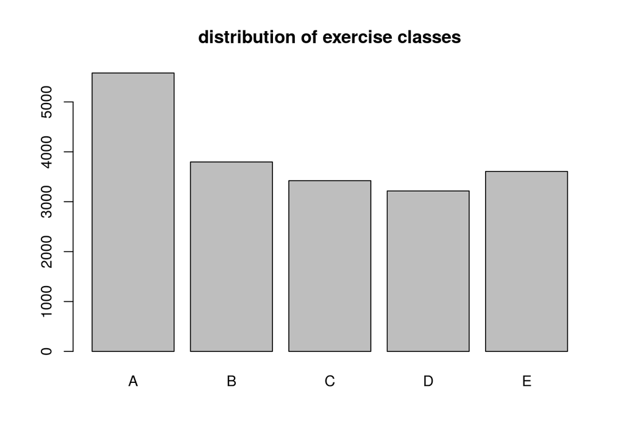

The data seems fairly evenly distributed. The pair-wise correlation plot of the predictor variables shows that there are a couple of medium correlations(yaw_dumbell-pitch_belt, yaw_belt-pitch_belt) and a strong one(yaw_belt-roll_belt).

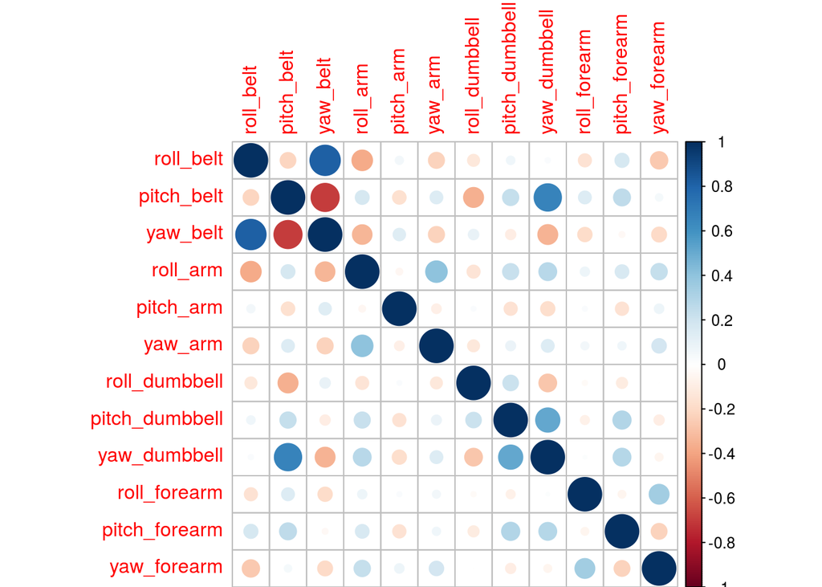

## Modelling

Since the problem in consideration is one of classification, we will attempt building two models, one based on bagging, i.e. a random forest, and the other based on boosting, i.e. a gradient boosted machine. Here are the details on how the models will be built.

### Random Forest(Bagging)

We will start with training a random forest model to predict our class. Random forests are generally robust to multicollinearity and handle missing values well, although in our case there are no missing values to worry about. We will use ‘caret’ package to train and tune our model. For the model, we will use a 5 fold cross validation with all other settings set to default.

Here we present the model summary.

```
## Random Forest
##
## 14718 samples
##    12 predictors
##     5 classes: 'A', 'B', 'C', 'D', 'E'
##
## No pre-processing
## Resampling: Cross-Validated (5 fold)
## Summary of sample sizes: 11775, 11774, 11774, 11774, 11775
## Resampling results across tuning parameters:
##
##   mtry  Accuracy   Kappa
##    2    0.9837616  0.9794602
##    7    0.9848487  0.9808376
##   12    0.9795491  0.9741344
##
## Accuracy was used to select the optimal model using  the largest value.
## The final value used for the model was mtry = 7.
```

```
##
## Call:
##  randomForest(x = x, y = y, mtry = param$mtry, verbose = ..1)
##                Type of random forest: classification
##                      Number of trees: 500
## No. of variables tried at each split: 7
##
##         OOB estimate of  error rate: 1.07%
## Confusion matrix:
##      A    B    C    D    E class.error
## A 4169   13    0    3    0 0.003823178
## B   15 2799   31    3    0 0.017205056
## C    0   22 2521   21    3 0.017919751
## D    2    3   13 2390    4 0.009121061
## E    0    7    9    9 2681 0.009238729
```

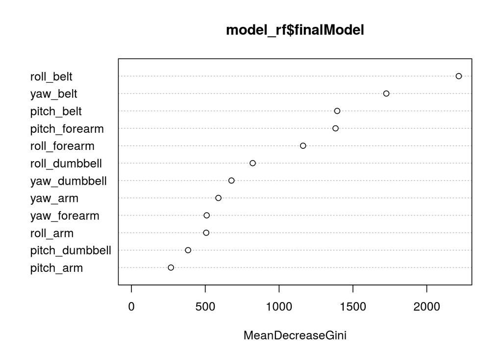

### GBM(Boosting)

The next model we will train is a gradient boosted machine. GBM models are also fairly robust to multicollinearity and missing values. We will use the ‘caret’ package to train and tune the model. We have chosen a 5-fold cross validation with a shrinkage of .01.

```
## Stochastic Gradient Boosting
##
## 14718 samples
##    12 predictors
##     5 classes: 'A', 'B', 'C', 'D', 'E'
##
## No pre-processing
## Resampling: Cross-Validated (5 fold)
## Summary of sample sizes: 11775, 11775, 11773, 11775, 11774
## Resampling results:
##
##   Accuracy   Kappa
##   0.9389862  0.9228785
##
## Tuning parameter 'n.trees' was held constant at a value of 2000
##  3
## Tuning parameter 'shrinkage' was held constant at a value of
##  0.01
## Tuning parameter 'n.minobsinnode' was held constant at a value of 100
```

```
##                   Overall
## roll_belt      50460.8511
## pitch_belt     17987.2805
## yaw_belt       30926.5816
## roll_arm        3965.0363
## pitch_arm        999.7608
## yaw_arm         5217.3603
## roll_dumbbell  12652.4010
## pitch_dumbbell  4039.3311
## yaw_dumbbell    5988.9047
## roll_forearm   17221.5160
## pitch_forearm  29756.2551
## yaw_forearm     2693.1119
```

## Model Evaluation

We have trained the models. We will now evaluate the models on unseen data and generate and estimate of OOS error. Here we present the output of model fit on validation set.

Random Forest evaluation

```
## Confusion Matrix and Statistics
##
##           Reference
## Prediction    A    B    C    D    E
##          A 1394    1    0    0    0
##          B    5  931   10    2    1
##          C    0    3  844    8    0
##          D    0    1    4  799    0
##          E    0    3    3    1  894
##
## Overall Statistics
##
##                Accuracy : 0.9914
##                  95% CI : (0.9884, 0.9938)
##     No Information Rate : 0.2853
##     P-Value [Acc > NIR] : < 2.2e-16
##
##                   Kappa : 0.9892
##  Mcnemar's Test P-Value : NA
##
## Statistics by Class:
##
##                      Class: A Class: B Class: C Class: D Class: E
## Sensitivity            0.9964   0.9915   0.9803   0.9864   0.9989
## Specificity            0.9997   0.9955   0.9973   0.9988   0.9983
## Pos Pred Value         0.9993   0.9810   0.9871   0.9938   0.9922
## Neg Pred Value         0.9986   0.9980   0.9958   0.9973   0.9998
## Prevalence             0.2853   0.1915   0.1756   0.1652   0.1825
## Detection Rate         0.2843   0.1898   0.1721   0.1629   0.1823
## Detection Prevalence   0.2845   0.1935   0.1743   0.1639   0.1837
## Balanced Accuracy      0.9981   0.9935   0.9888   0.9926   0.9986
```

GBM evaluation

```
## Confusion Matrix and Statistics
##
##           Reference
## Prediction    A    B    C    D    E
##          A 1351   31    6    5    2
##          B   31  869   37   10    2
##          C    1   34  791   23    6
##          D    1    8   17  773    5
##          E    3    9   12   13  864
##
## Overall Statistics
##
##                Accuracy : 0.9478
##                  95% CI : (0.9412, 0.9539)
##     No Information Rate : 0.2828
##     P-Value [Acc > NIR] : < 2e-16
##
##                   Kappa : 0.934
##  Mcnemar's Test P-Value : 0.06029
##
## Statistics by Class:
##
##                      Class: A Class: B Class: C Class: D Class: E
## Sensitivity            0.9740   0.9138   0.9166   0.9381   0.9829
## Specificity            0.9875   0.9798   0.9842   0.9924   0.9908
## Pos Pred Value         0.9685   0.9157   0.9251   0.9614   0.9589
## Neg Pred Value         0.9897   0.9793   0.9822   0.9876   0.9963
## Prevalence             0.2828   0.1939   0.1760   0.1680   0.1792
## Detection Rate         0.2755   0.1772   0.1613   0.1576   0.1762
## Detection Prevalence   0.2845   0.1935   0.1743   0.1639   0.1837
## Balanced Accuracy      0.9808   0.9468   0.9504   0.9653   0.9869
```

## Conclusion

From the above results, it is evident that the Random forest model performed better than the gbm model on the validation data we used for evaluation. However, it does not necessarily mean that the random forest is better than a gbm. It is possible that with a little tuning, we may be able to achieve similar or even better results using the GBM. Although, we will not be doing that in this report. We now come to the end of this exercise(No pun intended!)

## Appendix

[1] The data used in the analysis came from this source http://web.archive.org/web/20161224072740/http:/groupware.les.inf.puc-rio.br/har

[2] Details of the variables in the input dataset

```
## 'data.frame':    19622 obs. of  160 variables:
##  $ X                       : int  1 2 3 4 5 6 7 8 9 10 ...
##  $ user_name               : chr  "carlitos" "carlitos" "carlitos" "carlitos" ...
##  $ raw_timestamp_part_1    : int  1323084231 1323084231 1323084231 1323084232 1323084232 1323084232 1323084232 1323084232 1323084232 1323084232 ...
##  $ raw_timestamp_part_2    : int  788290 808298 820366 120339 196328 304277 368296 440390 484323 484434 ...
##  $ cvtd_timestamp          : chr  "05/12/2011 11:23" "05/12/2011 11:23" "05/12/2011 11:23" "05/12/2011 11:23" ...
##  $ new_window              : chr  "no" "no" "no" "no" ...
##  $ num_window              : int  11 11 11 12 12 12 12 12 12 12 ...
##  $ roll_belt               : num  1.41 1.41 1.42 1.48 1.48 1.45 1.42 1.42 1.43 1.45 ...
##  $ pitch_belt              : num  8.07 8.07 8.07 8.05 8.07 8.06 8.09 8.13 8.16 8.17 ...
##  $ yaw_belt                : num  -94.4 -94.4 -94.4 -94.4 -94.4 -94.4 -94.4 -94.4 -94.4 -94.4 ...
##  $ total_accel_belt        : int  3 3 3 3 3 3 3 3 3 3 ...
##  $ kurtosis_roll_belt      : chr  "" "" "" "" ...
##  $ kurtosis_picth_belt     : chr  "" "" "" "" ...
##  $ kurtosis_yaw_belt       : chr  "" "" "" "" ...
```

[output cut: 146 more lines]